# Reproducible Research: Peer Assessment 1

## Loading Data

```r
library(dplyr)
activity_data <- read.csv("/Users/fezekilemdluli/Coursera/reproducible-research/activity.csv")
activity_data$date<-as.Date(activity_data$date,tz="")
```

## What is mean total number of steps taken per day?

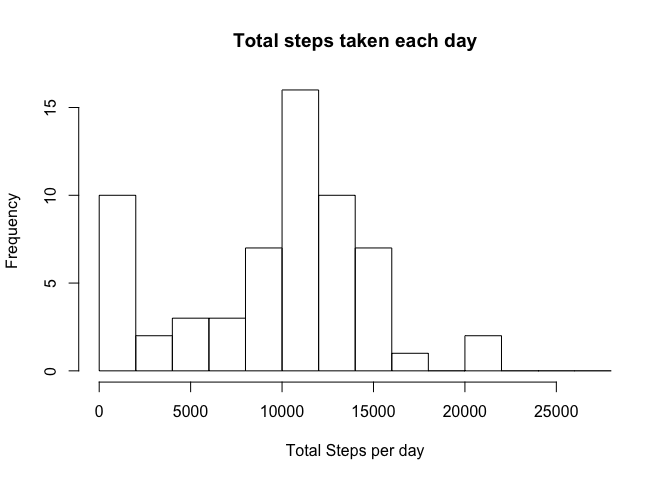

```r
total_steps_per_day <- with(activity_data, aggregate(steps,list(date),FUN = sum,na.rm=TRUE))

colnames(total_steps_per_day)<- c("date", "steps")

hist(total_steps_per_day$steps, xlab = "Total Steps per day", main = "Total steps taken each day",breaks = seq(0,28000, by=2000))
```

```r
mean_steps <- mean(total_steps_per_day$steps, na.rm= TRUE)

median_steps <- median(total_steps_per_day$steps, na.rm= TRUE)
```

- The Mean is 9354.2295082
- The Median is 10395

## What is the average daily activity pattern?

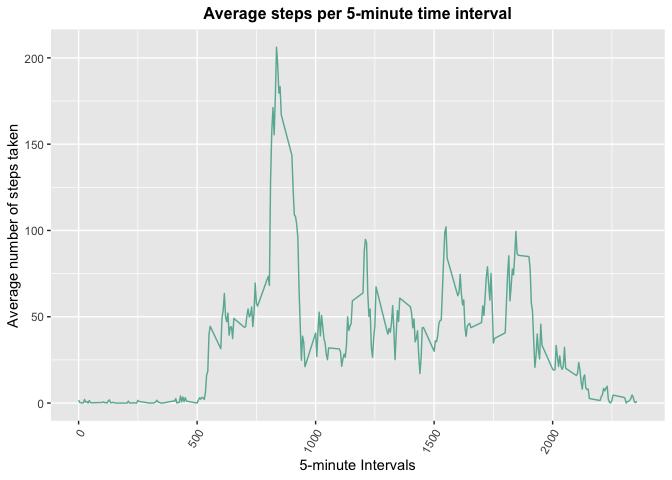

```r
library(ggplot2)

activity_subset<- aggregate(steps ~ interval, data = activity_data, FUN = mean, na.action = na.omit)
colnames(activity_subset) <- c("interval", "steps")


p <-ggplot(activity_subset, aes(activity_subset$interval, activity_subset$steps))
p + geom_line(color='#69b3a2') +
    xlab ('5-minute Intervals')+
    ylab('Average number of steps taken')+
    theme(axis.text.x=element_text(angle=60, hjust=1))+
  theme(plot.title = element_text(face = "bold", size = 12, hjust = 0.5)) +
  ggtitle('Average steps per 5-minute time interval')
```

2. Which 5-minute interval, on average across all the days in the dataset, contains the maximum number of steps?

```r
max_step_interval <-activity_subset[activity_subset$steps == max(activity_subset$steps), ]$interval

max_step_interval
```

```
## [1] 835
```

## Imputing missing values

1. Calculate and report the total number of missing values in the dataset (i.e. the total number of rows with NAs)

```r
missing_values <- sum(is.na(activity_data$steps)==TRUE)
```

- The the total number of missing values in the dataset is 2304

```r
activity_data$complete <- ifelse(is.na(activity_data$steps),round(activity_subset$steps[match(activity_data$interval,activity_subset$interval)],0),activity_data$steps)
```

Create a new dataset that is equal to the original but with missing values filled in.

```r
new_dataset <-data.frame(steps=activity_data$complete,date=activity_data$date, interval = activity_data$interval)
head(new_dataset,10)
```

```
##    steps       date interval
## 1      2 2012-10-01        0
## 2      0 2012-10-01        5
## 3      0 2012-10-01       10
## 4      0 2012-10-01       15
## 5      0 2012-10-01       20
## 6      2 2012-10-01       25
## 7      1 2012-10-01       30
## 8      1 2012-10-01       35
## 9      0 2012-10-01       40
## 10     1 2012-10-01       45
```

Make a histogram of the total number of steps taken each day and Calculate and report the mean and median total number of steps taken per day. Do these values differ from the estimates from the first part of the assignment? What is the impact of imputing missing data on the estimates of the total daily number of steps?

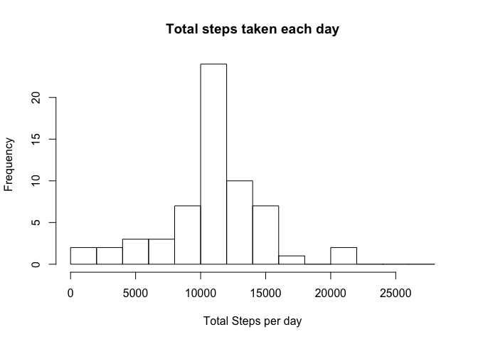

```r
complete_steps_per_day <- with(new_dataset, aggregate(steps,list(date),FUN = sum,na.rm=TRUE))
#complete_steps_per_day <-  aggregate(new_dataset$steps,list(new_dataset$date),FUN = sum)

colnames(complete_steps_per_day)<- c("date", "steps")

hist(complete_steps_per_day$steps, xlab = "Total Steps per day", main = "Total steps taken each day",breaks = seq(0,28000, by=2000))
```

Calculate Mean and Median using completed data

```r
imp_mean<-mean(complete_steps_per_day$steps)
imp_mean
```

```
## [1] 10765.64
```

```r
imp_median<- median(complete_steps_per_day$steps)
imp_median
```

```
## [1] 10762
```

Comarison of Mean and Median

Both the Mean and Median have slightly increased after filling the missing values.

## Are there differences in activity patterns between weekdays and weekends?

1. Create a new factor variable in the dataset with two levels – “weekday” and “weekend” indicating whether a given date is a weekday or weekend day

```r
day_of_the_week <-weekdays(new_dataset$date, abbreviate = FALSE)
new_dataset<-cbind(new_dataset,day_of_the_week)

day_factor <-ifelse(new_dataset$day_of_the_week == 'Saturday'| new_dataset$day_of_the_week=="Sunday", "Weekend", "Weekday")

new_dataset<-cbind(new_dataset,day_factor)


head(new_dataset)
```

```
##   steps       date interval day_of_the_week day_factor
## 1     2 2012-10-01        0          Monday    Weekday
## 2     0 2012-10-01        5          Monday    Weekday
## 3     0 2012-10-01       10          Monday    Weekday
## 4     0 2012-10-01       15          Monday    Weekday
## 5     0 2012-10-01       20          Monday    Weekday
## 6     2 2012-10-01       25          Monday    Weekday
```

Make a panel plot containing a time series plot (i.e. type = “l”) of the 5-minute interval (x-axis) and the average number of steps taken, averaged across all weekday days or weekend days (y-axis).

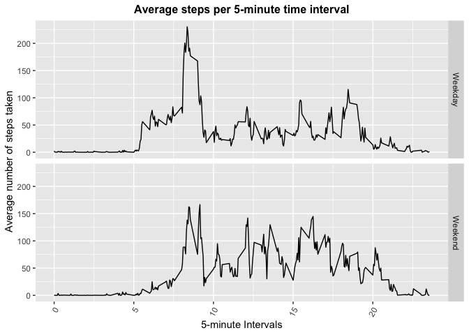

```r
activity_subset2<- aggregate(steps ~ interval + day_factor, data = new_dataset, FUN = mean, na.action = na.omit)

p <-ggplot(activity_subset2, aes(activity_subset2$interval/100, activity_subset2$steps))
p + geom_line(bg='#69b3a2') +
    xlab ('5-minute Intervals')+
    ylab('Average number of steps taken')+
    theme(axis.text.x=element_text(angle=60, hjust=1))+
  theme(plot.title = element_text(face = "bold", size = 12, hjust = 0.5)) +
  ggtitle('Average steps per 5-minute time interval')+
  facet_grid(day_factor ~ .)
```